# imcExperiment: containerization of IMC data

Anthony Colombo

09 January, 2021

# Heatmap plotting script (helper)

- The heatmap function we do not want to include with this package, but here is the helper function.

```r
library(dplyr)
library(RColorBrewer)
library(pheatmap)
library(magrittr)
library(igraph)

 ##the rows of the IMC container input are the protein antibody panel, the columns are the cells. (need to transpose for matrix computatoins)
plot_clustering_heatmap_wrapper<-function(myExperiment=NULL,
  useMedians=TRUE,
 color_clusters=NULL){

  expr<-(cellIntensity(myExperiment))
  cell_clustering<-(getNetwork(myExperiment))

   expr<-t(as.matrix(expr))

 if(is.null(color_clusters)==TRUE){
  color_clusters <- c("#DC050C", "#FB8072", "#1965B0", "#7BAFDE", "#882E72",
  "#B17BA6", "#FF7F00", "#FDB462", "#E7298A", "#E78AC3",
  "#33A02C", "#B2DF8A", "#55A1B1", "#8DD3C7", "#A6761D",
  "#E6AB02", "#7570B3", "#BEAED4", "#666666", "#999999",
  "#aa8282", "#d4b7b7", "#8600bf", "#ba5ce3", "#808000",
  "#aeae5c", "#1e90ff", "#00bfff", "#56ff0d", "#ffff00")
 }

  # Calculate the median expression
  expr_median <- data.frame(expr, cell_clustering = cell_clustering) %>%
    group_by(cell_clustering) %>%
    summarize_all(funs(median))

  if(useMedians==TRUE){
  expr_median <- data.frame(expr, cell_clustering = cell_clustering) %>%
    group_by(cell_clustering) %>%
    summarize_all(funs(median))
   }else{
   expr_median <- data.frame(expr, cell_clustering = cell_clustering) %>%
    group_by(cell_clustering) %>%
    summarize_all(funs(mean))
 }
  # Calculate cluster frequencies
  clustering_table <- as.numeric(table(cell_clustering))

  # This clustering is based on the markers that were used for the main clustering
  d <- dist(expr_median[, colnames(expr)], method = "euclidean")
  cluster_rows <- hclust(d, method = "average")
   expr_heat <- as.matrix(expr_median[, colnames(expr)])
  rownames(expr_heat) <- expr_median$cell_clustering

  labels_row <- paste0(rownames(expr_heat), " (",
    round(clustering_table / sum(clustering_table) * 100, 2), "%)")
  labels_col <- colnames(expr_heat)

  # Row annotation for the heatmap
  annotation_row <- data.frame(cluster = factor(expr_median$cell_clustering))
  rownames(annotation_row) <- rownames(expr_heat)

  color_clusters <- color_clusters[1:nlevels(annotation_row$cluster)]
  names(color_clusters) <- levels(annotation_row$cluster)
  annotation_colors <- list(cluster = color_clusters)
  annotation_legend <- FALSE

  # Colors for the heatmap
  #library(RColorBrewer);
  color <- colorRampPalette(rev(brewer.pal(n = 9, name = "RdYlBu")))(100)

  pheatmap(expr_heat, color = color,
    cluster_cols = FALSE, cluster_rows = cluster_rows,
    labels_col = labels_col, labels_row = labels_row,
    display_numbers = TRUE, number_color = "black",
    fontsize = 12, fontsize_number = 12,
    annotation_row = annotation_row, annotation_colors = annotation_colors,
    annotation_legend = annotation_legend)
}




plot_matrix_heatmap_wrapper<-function(expr=NULL,
  cell_clustering=NULL, cluster_merging = NULL,useMedians=TRUE,useQuantiles=FALSE,
color_clusters=NULL){
  ## cluster_merging should be character merging vector of 29 or so clusters. this is input from the ANNOTATION object.  not a matched object level.
   expr<-as.matrix(expr)
  if(useQuantiles==TRUE){
  ##max min normalization
  library(matrixStats)
  rng <- colQuantiles(expr, probs = c(0.001, 0.999))
  expr01 <- t((t(expr) - rng[, 1]) / (rng[, 2] - rng[, 1]))
  expr01[expr01 < 0] <- 0
  expr01[expr01 > 1] <- 1
  }else{
   expr01<-expr

  }

 if(is.null(color_clusters)==TRUE){
  color_clusters <- c("#DC050C", "#FB8072", "#1965B0", "#7BAFDE", "#882E72",
  "#B17BA6", "#FF7F00", "#FDB462", "#E7298A", "#E78AC3",
  "#33A02C", "#B2DF8A", "#55A1B1", "#8DD3C7", "#A6761D",
  "#E6AB02", "#7570B3", "#BEAED4", "#666666", "#999999",
  "#aa8282", "#d4b7b7", "#8600bf", "#ba5ce3", "#808000",
  "#aeae5c", "#1e90ff", "#00bfff", "#56ff0d", "#ffff00")
 }

  # Calculate the median expression
  library(dplyr)
  expr_median <- data.frame(expr, cell_clustering = cell_clustering) %>%
   dplyr::group_by(cell_clustering) %>%
    dplyr::summarize_all(funs(median))
 if(useMedians==TRUE){
  expr01_median <- data.frame(expr01, cell_clustering = cell_clustering) %>%
    group_by(cell_clustering) %>%
    dplyr::summarize_all(funs(median))
   }else{
   expr01_median <- data.frame(expr01, cell_clustering = cell_clustering) %>%
    dplyr::group_by(cell_clustering) %>%
   dplyr::summarize_all(funs(mean))
 }
  # Calculate cluster frequencies
  clustering_table <- as.numeric(table(cell_clustering))
   print(dim(expr_median))
  # This clustering is based on the markers that were used for the main clustering
  d <- dist(expr_median[, colnames(expr)], method = "euclidean")
  cluster_rows <- hclust(d, method = "average")
   expr_heat <- as.matrix(expr01_median[, colnames(expr01)])
  rownames(expr_heat) <- expr01_median$cell_clustering

  labels_row <- paste0(rownames(expr_heat), " (",
    round(clustering_table / sum(clustering_table) * 100, 2), "%)")
  labels_col <- colnames(expr_heat)

  # Row annotation for the heatmap
  annotation_row <- data.frame(cluster = factor(expr01_median$cell_clustering))
  rownames(annotation_row) <- rownames(expr_heat)

  color_clusters <- color_clusters[1:nlevels(annotation_row$cluster)]
  names(color_clusters) <- levels(annotation_row$cluster)
  annotation_colors <- list(cluster = color_clusters)
  annotation_legend <- FALSE

  if(!is.null(cluster_merging)){

    annotation_row$cluster_merging <- factor(cluster_merging)
    color_clusters <- color_clusters[1:nlevels(factor(cluster_merging))]
    names(color_clusters) <- levels(factor(cluster_merging))
    annotation_colors$cluster_merging <- color_clusters
    annotation_legend <- TRUE
  }

  # Colors for the heatmap
  library(RColorBrewer);library(pheatmap)
  color <- colorRampPalette(rev(brewer.pal(n = 9, name = "RdYlBu")))(100)

  pheatmap::pheatmap(expr_heat, color = color,
    cluster_cols = FALSE, cluster_rows = cluster_rows,
    labels_col = labels_col, labels_row = labels_row,
    display_numbers = TRUE, number_color = "black",
    fontsize = 10, fontsize_number = 7,
    annotation_row = annotation_row, annotation_colors = annotation_colors,
    annotation_legend = annotation_legend)

}
```

# example

- The IMC container contains slots for intensity, coordinates, neighborhood features, networking ID, distance measures, morphology, unique cell labels, panel information, and ROIID.
- The input to the imcExperiment object has the cells (columns) and rows are the proteins.
- For spatial features, the rows are the cells, and columns are the spatial features. the 2-dim coordinates (x,y), neighborHood features, network assignment, unique Label, ROIID, and distance matrix. These data are required for the constructure but can be edited later.
- The IMC container inherits many function used for SummarizedExperiment classes (assays, etc).

```r
 library(imcExperiment)
  #10 cells with 10 proteins
  # 10 neighbors
 # and square distance matrix
 # note that for SCE objects the columns are the cells, and rows are proteins
  x<-imcExperiment(cellIntensity=matrix(1,nrow=10,ncol=10),
    coordinates=matrix(1,nrow=10,ncol=2),
    neighborHood=matrix(1,nrow=10,ncol=10),
    network=matrix(1,nrow=10,ncol=10),
    distance=matrix(1,nrow=10,ncol=10),
    morphology=matrix(1,nrow=10,ncol=10),
    uniqueLabel=paste0("A",seq(1,10)),
    panel=letters[1:10],
    ROIID=data.frame(ROIID=rep("A",10)))


 #7 cells with 10 proteins
 # but the spatial information is 10 rows and this will fail to build.
 #x<-imcExperiment(cellIntensity=matrix(1,nrow=7,ncol=10),
#   coordinates=matrix(1,nrow=10,ncol=2),
#   neighborHood=matrix(1,nrow=10,ncol=20),
#   network=matrix(1,nrow=10,ncol=3),
#   distance=matrix(1,nrow=10,ncol=2),
#   uniqueLabel=rep("A",10),
#   ROIID=data.frame(ROIID=rep("A",10)))
```

### Accessors, and setters

- the cellIntensity() function accesses cell Intensity
- getCoordinates() accesses spatial data.
- getNeighborhood() access the histoCAT neighborhood features
- getDistance() accesses distance matrix input.
- getMorphology() accesses morphology features.
- the metadata() function can store extras .

```r
  #get cellintensities
  cellIntensity(x)
```

```
##       [,1] [,2] [,3] [,4] [,5] [,6] [,7] [,8] [,9] [,10]
##  [1,]    1    1    1    1    1    1    1    1    1     1
##  [2,]    1    1    1    1    1    1    1    1    1     1
##  [3,]    1    1    1    1    1    1    1    1    1     1
##  [4,]    1    1    1    1    1    1    1    1    1     1
##  [5,]    1    1    1    1    1    1    1    1    1     1
##  [6,]    1    1    1    1    1    1    1    1    1     1
##  [7,]    1    1    1    1    1    1    1    1    1     1
##  [8,]    1    1    1    1    1    1    1    1    1     1
##  [9,]    1    1    1    1    1    1    1    1    1     1
## [10,]    1    1    1    1    1    1    1    1    1     1
```

```r
  #set intensities
  newIn<-matrix(rnorm(100,2,5),nrow=10,ncol=10)
  rownames(newIn)<-rownames(x)
  colnames(newIn)<-colnames(x)
   cellIntensity(x)<-newIn
  cellIntensity(x)==newIn
```

```
##     A1   A2   A3   A4   A5   A6   A7   A8   A9  A10
## a TRUE TRUE TRUE TRUE TRUE TRUE TRUE TRUE TRUE TRUE
## b TRUE TRUE TRUE TRUE TRUE TRUE TRUE TRUE TRUE TRUE
## c TRUE TRUE TRUE TRUE TRUE TRUE TRUE TRUE TRUE TRUE
## d TRUE TRUE TRUE TRUE TRUE TRUE TRUE TRUE TRUE TRUE
## e TRUE TRUE TRUE TRUE TRUE TRUE TRUE TRUE TRUE TRUE
## f TRUE TRUE TRUE TRUE TRUE TRUE TRUE TRUE TRUE TRUE
## g TRUE TRUE TRUE TRUE TRUE TRUE TRUE TRUE TRUE TRUE
## h TRUE TRUE TRUE TRUE TRUE TRUE TRUE TRUE TRUE TRUE
## i TRUE TRUE TRUE TRUE TRUE TRUE TRUE TRUE TRUE TRUE
## j TRUE TRUE TRUE TRUE TRUE TRUE TRUE TRUE TRUE TRUE
```

```r
 # if we want to store both the raw and normalized values in assays we can.
  assays(x,withDimnames = FALSE)$raw<-matrix(1,nrow=10,ncol=10)
  #store the normalized values.
   cellIntensity(x)<-asinh(counts(x)/0.5)
   all(cellIntensity(x)==asinh(assays(x)$counts/0.5))
```

```
## [1] TRUE
```

```r
  x
```

```
## class: imcExperiment
## dim: 10 10
## metadata(0):
## assays(2): counts raw
## rownames(10): a b ... i j
## rowData names(0):
## colnames(10): A1 A2 ... A9 A10
## colData names(1): ROIID
## reducedDimNames(0):
## altExpNames(0):
```

```r
 ## access the coordinates
  getCoordinates(x)
```

```
##       [,1] [,2]
##  [1,]    1    1
##  [2,]    1    1
##  [3,]    1    1
##  [4,]    1    1
##  [5,]    1    1
##  [6,]    1    1
##  [7,]    1    1
##  [8,]    1    1
##  [9,]    1    1
## [10,]    1    1
```

```r
  getCoordinates(x)<-matrix(rnorm(20,0,10),nrow=10,ncol=2)
head(  getCoordinates(x))
```

```
##            [,1]       [,2]
## [1,]  6.0103551   8.702493
## [2,]  9.2135526  -1.635814
## [3,] -8.9625474  11.864597
## [4,]  0.1881764  19.751015
## [5,] -1.3162271 -12.771618
## [6,] -6.8877381 -21.394094
```

```r
 ## access the neighborhood profile.  Note each row must equal the number of cells, but the columns can be extended depending on the radius of interactions.
  ## access the coordinates
  getNeighborhood(x)
```

```
##       [,1] [,2] [,3] [,4] [,5] [,6] [,7] [,8] [,9] [,10]
##  [1,]    1    1    1    1    1    1    1    1    1     1
##  [2,]    1    1    1    1    1    1    1    1    1     1
##  [3,]    1    1    1    1    1    1    1    1    1     1
##  [4,]    1    1    1    1    1    1    1    1    1     1
##  [5,]    1    1    1    1    1    1    1    1    1     1
##  [6,]    1    1    1    1    1    1    1    1    1     1
##  [7,]    1    1    1    1    1    1    1    1    1     1
##  [8,]    1    1    1    1    1    1    1    1    1     1
##  [9,]    1    1    1    1    1    1    1    1    1     1
## [10,]    1    1    1    1    1    1    1    1    1     1
```

```r
  getNeighborhood(x)<-matrix(rnorm(100,1,5),nrow=10,ncol=10)
 head( getNeighborhood(x))
```

```
##            [,1]      [,2]      [,3]       [,4]       [,5]      [,6]      [,7]
## [1,]   3.558738  4.287510  1.560554 10.2783125   5.732261  1.408318  2.345832
## [2,] -14.247866 -1.202638  7.145390 -1.5715187  -2.248787  2.020583  1.059178
## [3,]   3.270507  6.804342 -6.611953 -1.0095442 -10.158653  8.902811 -2.709457
## [4,]  11.653382  2.265055  3.615694 11.1444862   4.152296 -2.107428  4.509682
## [5,]  11.145141  9.705598  5.117248  0.3163326  -2.488621  6.529012 -1.025992
## [6,]   3.095212  2.434195  2.603567  0.1311309   2.606966  3.983601  1.105987
##            [,8]       [,9]      [,10]
## [1,] -2.1611140  2.7240694 -5.7459239
## [2,]  4.5078368 -0.2368595  4.1754482
## [3,]  2.1470819  3.9087365 12.5562966
## [4,]  2.4802833 -1.1723138  5.8505437
## [5,] -5.8803923  1.6442194  0.3979806
## [6,]  0.6858971  4.6243017  2.3183210
```

```r
 ## get the distance usually a square matrix, or can be just first nearest etc.
    getDistance(x)
```

```
##       [,1] [,2] [,3] [,4] [,5] [,6] [,7] [,8] [,9] [,10]
##  [1,]    1    1    1    1    1    1    1    1    1     1
##  [2,]    1    1    1    1    1    1    1    1    1     1
##  [3,]    1    1    1    1    1    1    1    1    1     1
##  [4,]    1    1    1    1    1    1    1    1    1     1
##  [5,]    1    1    1    1    1    1    1    1    1     1
##  [6,]    1    1    1    1    1    1    1    1    1     1
##  [7,]    1    1    1    1    1    1    1    1    1     1
##  [8,]    1    1    1    1    1    1    1    1    1     1
##  [9,]    1    1    1    1    1    1    1    1    1     1
## [10,]    1    1    1    1    1    1    1    1    1     1
```

```r
  getDistance(x)<-matrix(rnorm(100,1,5),nrow=10,ncol=10)
  head(getDistance(x))
```

```
##            [,1]      [,2]      [,3]        [,4]      [,5]       [,6]       [,7]
## [1,] -3.8351795 -7.088155  1.309708  5.55712995 -3.015817 -10.947491 -1.5172288
## [2,]  2.7086004  6.413144  2.761343 -7.26509461  2.870784   3.486787  8.4919008
## [3,] -4.6748431  5.091270  5.759481  4.61065788  1.719509  -2.546972 -2.6471549
## [4,] -0.6008088  4.123392  3.171155 -0.08262693  2.044111   4.191319 -5.2884547
## [5,]  1.4269338  6.356949 -3.189593  5.27113119  1.253909  -3.010759 -4.0477877
## [6,] -2.0188569  2.297714 -3.214427  7.71778416  1.414514  -5.041848 -0.7277195
##            [,8]      [,9]       [,10]
## [1,]  2.3335864 14.449007   8.2291589
## [2,]  0.5842695  6.131462   6.4667814
## [3,]  4.0437313 -6.895784  -0.3582424
## [4,] -1.7746277 -2.848188 -11.1204415
## [5,]  2.7647125 -7.175480   9.9394002
## [6,]  4.2008674 -2.293389   3.8072453
```

```r
 # get morphological features
  getMorphology(x)
```

```
##       [,1] [,2] [,3] [,4] [,5] [,6] [,7] [,8] [,9] [,10]
##  [1,]    1    1    1    1    1    1    1    1    1     1
##  [2,]    1    1    1    1    1    1    1    1    1     1
##  [3,]    1    1    1    1    1    1    1    1    1     1
##  [4,]    1    1    1    1    1    1    1    1    1     1
##  [5,]    1    1    1    1    1    1    1    1    1     1
##  [6,]    1    1    1    1    1    1    1    1    1     1
##  [7,]    1    1    1    1    1    1    1    1    1     1
##  [8,]    1    1    1    1    1    1    1    1    1     1
##  [9,]    1    1    1    1    1    1    1    1    1     1
## [10,]    1    1    1    1    1    1    1    1    1     1
```

```r
  getMorphology(x)<-matrix(rnorm(100,1,5),nrow=10,ncol=60)
  head(getMorphology(x))
```

```
##           [,1]       [,2]        [,3]       [,4]      [,5]       [,6]
## [1,]  6.683686  9.0534066  1.11964929 -5.0317872 -5.550246  -5.977626
## [2,]  1.439058 -7.0708230 10.38320402  8.5560721 -2.406810  -1.387758
## [3,] -4.395764 -4.4283779  0.85974299  0.2835862 -4.705614  -2.683992
## [4,]  1.987880  8.5121221 -2.13026406  0.6105430 -1.600873   3.706665
## [5,]  2.975548  0.8694269 -0.07161229 -4.0787605  7.083538 -10.207163
## [6,]  5.062162 -1.7596740 -4.73303711 -3.8517334 -5.773144   5.084180
##            [,7]       [,8]      [,9]     [,10]     [,11]      [,12]       [,13]
## [1,]  5.4087453  2.2740076 -4.679950 -1.662703  6.683686  9.0534066  1.11964929
## [2,]  9.8161919  5.4555263  4.071155 -1.580045  1.439058 -7.0708230 10.38320402
## [3,] -1.7108078  1.5412890 -9.089039 -4.143855 -4.395764 -4.4283779  0.85974299
## [4,]  0.8165124  4.6016162 -1.119997  2.768936  1.987880  8.5121221 -2.13026406
## [5,] -3.3717255 -0.5081251  5.931802  2.284748  2.975548  0.8694269 -0.07161229
## [6,] -1.9509796 -0.2258124 -2.054731 -5.485278  5.062162 -1.7596740 -4.73303711
##           [,14]     [,15]      [,16]      [,17]      [,18]     [,19]     [,20]
```

[output cut: 48 more lines]

```r
 ## for each cell we can obtain the ROI that it belongs to
  rowData(x)
```

```
## DataFrame with 10 rows and 0 columns
```

```r
 ## if we want to add patient features to each ROI we can
  metas<-data.frame(ROIID=factor(rep("A",10)),treatment=factor(rep('none',10)))
  colData(x)<-DataFrame(metas)

 ##other slots for covariates
   metadata(x)$experiment<-'test'
   metadata(x)
```

```
## $experiment
## [1] "test"
```

### From histoCAT to R

- We use the raw histoCAT output and containerize the data.

```r
  ### load the data from package.
  library(imcExperiment)
 ##load the data 1000 cells from IMC experiment.
  data(data)
  dim(data)
```

```
## [1] 1000   73
```

```r
  ##output from histoCAT to R
  expr<-data[,3:36]
  normExp<-percentilenormalize(data=expr,percentile=0.99)
  normExp<-as.matrix(normExp)


  ##spatial component
  spatial<-(data[,c("X_position","Y_position")])
  spatial<-as.matrix(spatial)
 ##uniqueLabel
  uniqueLabel<-paste0(data[,"ImageId"],"_",data[,"CellId"])

 phenotypes<-as.matrix(data[,grepl("Phenograph",colnames(data))])
 morph<-as.matrix(data[,c("Area","Eccentricity",
    "Solidity",
    "Extent",
    "Perimeter")])

  x<-imcExperiment(cellIntensity=t(normExp),
    coordinates=spatial,
    neighborHood=as.matrix(data[,grepl("neighbour_",colnames(data))]),
    network=phenotypes,
    distance=matrix(1,nrow=nrow(data),ncol=10),
    morphology=morph,
    panel=colnames(normExp),
    uniqueLabel=paste0(data$ImageId,"_",data$CellId),
    ROIID=data.frame(ROIID=data$ImageId))

 ## explore the container.
  dim(assay(x))
```

```
## [1]   34 1000
```

```r
   colData(x)$treatment<-DataFrame(treatment=rep('none',1000))
   head(colData(x))
```

```
## DataFrame with 6 rows and 2 columns
##              ROIID   treatment
##          <integer> <DataFrame>
## 274864_1    274864        none
## 274864_2    274864        none
## 274864_3    274864        none
## 274864_4    274864        none
## 274864_5    274864        none
## 274864_6    274864        none
```

```r
 head( colnames(x))
```

```
## [1] "274864_1" "274864_2" "274864_3" "274864_4" "274864_5" "274864_6"
```

```r
  rownames(x)
```

```
##  [1] "Cell_CCR4Sm149Di_Sm149"      "Cell_CD15Dy164Di_Dy164"
##  [3] "Cell_CD16Nd146Di_Nd146"      "Cell_CD206Tm169Di_Tm169"
##  [5] "Cell_CD20Sm147Di_Sm147"      "Cell_CD30Ho165Di_Ho165"
##  [7] "Cell_CD31Nd144Di_Nd144"      "Cell_CD34Sm152Di_Sm152"
##  [9] "Cell_CD3Er170Di_Er170"       "Cell_CD45RAGd155Di_Gd155"
## [11] "Cell_CD45ROYb173Di_Yb173"    "Cell_CD4Gd156Di_Gd156"
## [13] "Cell_CD68Tb159Di_Tb159"      "Cell_CD8Dy162Di_Dy162"
## [15] "Cell_CXCR3Nd142Di_Nd142"     "Cell_CXCR5Yb171Di_Yb171"
## [17] "Cell_DNA2Ir191Di_Ir191"      "Cell_DNAIr193Di_Ir193"
## [19] "Cell_EphrinB2Er166Di_Er166"  "Cell_FOXP3Dy163Di_Dy163"
## [21] "Cell_GranzymBEr167Di_Er167"  "Cell_HLADRYb174Di_Yb174"
## [23] "Cell_Histone3Gd160Di_Gd160"  "Cell_ICOSNd148Di_Nd148"
## [25] "Cell_Ki67Er168Di_Er168"      "Cell_Lag3Eu153Di_Eu153"
## [27] "Cell_MembraneIn115Di_In115"  "Cell_PD1NAT105Lu175Di_Lu175"
## [29] "Cell_PDL1Nd150Di_Nd150"      "Cell_PDL2Yb172Di_Yb172"
## [31] "Cell_TbetNd145Di_Nd145"      "Cell_Tim3Sm154Di_Sm154"
## [33] "Cell_VimentinNd143Di_Nd143"  "Cell_pStat3Gd158Di_Gd158"
```

```r
  ## Intensity
  all(t(cellIntensity(x))==normExp)
```

```
## [1] TRUE
```

```r
  head(t(cellIntensity(x)))
```

```
##   Cell_CCR4Sm149Di_Sm149 Cell_CD15Dy164Di_Dy164 Cell_CD16Nd146Di_Nd146
## 1              0.4656571              0.2736824              0.7237669
## 2              0.3487101              0.2897530              0.3958101
## 3              0.8883986              0.7622286              0.8866145
## 4              0.3963552              0.1451175              0.2714126
## 5              0.5407341              0.2522549              0.4221974
## 6              1.0000000              0.7622286              0.0000000
##   Cell_CD206Tm169Di_Tm169 Cell_CD20Sm147Di_Sm147 Cell_CD30Ho165Di_Ho165
## 1               0.5204605              0.6330375             0.45935533
## 2               0.3548617              0.5588399             0.11483883
## 3               0.4873408              0.2400462             0.18374213
## 4               1.0000000              0.2100260             0.19686657
## 5               0.1064634              0.8991254             0.07655922
## 6               0.7854187              0.2018387             0.82683960
##   Cell_CD31Nd144Di_Nd144 Cell_CD34Sm152Di_Sm152 Cell_CD3Er170Di_Er170
```

[output cut: 69 more lines]

```r
  ##coordinate
  all(getCoordinates(x)==spatial)
```

```
## [1] TRUE
```

```r
  head(getCoordinates(x))
```

```
##   X_position Y_position
## 1   508.0000   3.000000
## 2   672.1667   3.000000
## 3   154.2000   4.200000
## 4   538.5714   4.857143
## 5   913.2778   3.444444
## 6  1200.0000   4.200000
```

```r
  #neighbor attraction data form histoCAT
 all(getNeighborhood(x)==as.matrix(data[,grepl("neighbour_",colnames(data))]))
```

```
## [1] TRUE
```

```r
 head(getNeighborhood((x)))
```

```
##   neighbour_4_CellId1 neighbour_4_CellId2 neighbour_4_CellId3
## 1                  36                 168                   0
## 2                 144                   0                   0
## 3                   0                   0                   0
## 4                  67                  92                   0
## 5                  13                  97                 249
## 6                 135                   0                   0
##   neighbour_4_CellId4 neighbour_4_CellId5 neighbour_4_CellId6
## 1                   0                   0                   0
## 2                   0                   0                   0
## 3                   0                   0                   0
## 4                   0                   0                   0
## 5                   0                   0                   0
## 6                   0                   0                   0
##   neighbour_4_CellId7 neighbour_4_CellId8 neighbour_4_CellId9
## 1                   0                   0                   0
## 2                   0                   0                   0
## 3                   0                   0                   0
## 4                   0                   0                   0
## 5                   0                   0                   0
## 6                   0                   0                   0
##   neighbour_4_CellId10
## 1                    0
## 2                    0
## 3                    0
## 4                    0
## 5                    0
## 6                    0
```

```r
 ##phenotype cluster ID
  head(getNetwork(x))
```

```
##   Phenograph7851534969 Phenograph852089651 Phenograph4113873397
## 1                    1                   5                    4
## 2                    1                   2                    2
## 3                    4                   1                    7
## 4                    4                   1                    7
## 5                    1                   2                    2
## 6                    1                   6                    8
##   Phenograph5190002862 Phenograph5238722970 Phenograph4732517031
## 1                    2                    1                   11
## 2                   14                   13                   17
## 3                   10                   12                   16
## 4                    1                   12                   16
## 5                    3                    6                    1
## 6                   24                   22                   24
```

```r
 all(getNetwork(x)==phenotypes)
```

```
## [1] TRUE
```

```r
 ###distance calculations
  head(getDistance(x))
```

```
##      [,1] [,2] [,3] [,4] [,5] [,6] [,7] [,8] [,9] [,10]
## [1,]    1    1    1    1    1    1    1    1    1     1
## [2,]    1    1    1    1    1    1    1    1    1     1
## [3,]    1    1    1    1    1    1    1    1    1     1
## [4,]    1    1    1    1    1    1    1    1    1     1
## [5,]    1    1    1    1    1    1    1    1    1     1
## [6,]    1    1    1    1    1    1    1    1    1     1
```

```r
  ##morphology
   all(getMorphology(x)==morph)
```

```
## [1] TRUE
```

```r
  head(getMorphology(x))
```

```
##   Area Eccentricity  Solidity    Extent Perimeter
## 1   21    0.6956573 0.9545455 0.8400000    13.844
## 2   24    0.8034622 0.9230769 0.6666667    16.565
## 3   15    0.9014174 1.0000000 0.7142857    12.918
## 4    7    0.8717717 0.8750000 0.5833333     7.683
## 5   18    0.9593719 0.7500000 0.3214286    19.766
## 6    5    0.7437865 1.0000000 0.5555556     5.814
```

```r
  ##uniqueLabel
   head(getLabel(x))
```

```
## [1] "274864_1" "274864_2" "274864_3" "274864_4" "274864_5" "274864_6"
```

```r
   all(getLabel(x)==paste0(data$ImageId,"_",data$CellId) )
```

```
## [1] TRUE
```

### PCA demo analysis

- PCA data and tSNE coordinates can be added to the container.

```r
 ### inherited accessor.
  pca_data <- prcomp(t(counts(x)), rank=50)
  reducedDims(x) <- list(PCA=pca_data$x, TSNE=data.frame(tsne.x=data$tSNE4148542692_1,tsne.y=data$tSNE4148542692_2))
   x
```

```
## class: imcExperiment
## dim: 34 1000
## metadata(0):
## assays(1): counts
## rownames(34): Cell_CCR4Sm149Di_Sm149 Cell_CD15Dy164Di_Dy164 ...
##   Cell_VimentinNd143Di_Nd143 Cell_pStat3Gd158Di_Gd158
## rowData names(0):
## colnames(1000): 274864_1 274864_2 ... 274864_999 274864_1000
## colData names(2): ROIID treatment
## reducedDimNames(2): PCA TSNE
## altExpNames(0):
```

```r
     dim(reducedDims(x)$PCA)
```

```
## [1] 1000   34
```

```r
     dim(reducedDims(x)$TSNE)
```

```
## [1] 1000    2
```

```r
 imc<-x
 x<-NULL
```

### IMC container and Phenograph cluster neighborhood

- Phenograph an IMC contrainer and heatmap result.

```r
 ### create  phenotypes via Rphenograph
  ##run phenograph
  library(Rphenograph)
  phenos<-Rphenograph(t(cellIntensity(imc)),k=35)
   pheno.labels<-as.numeric(membership(phenos[[2]]))
   getNetwork(imc)<-matrix(pheno.labels)
   head( getNetwork(imc))
```

```
##      [,1]
## [1,]    5
## [2,]    1
## [3,]    5
## [4,]    5
## [5,]    4
## [6,]    4
```

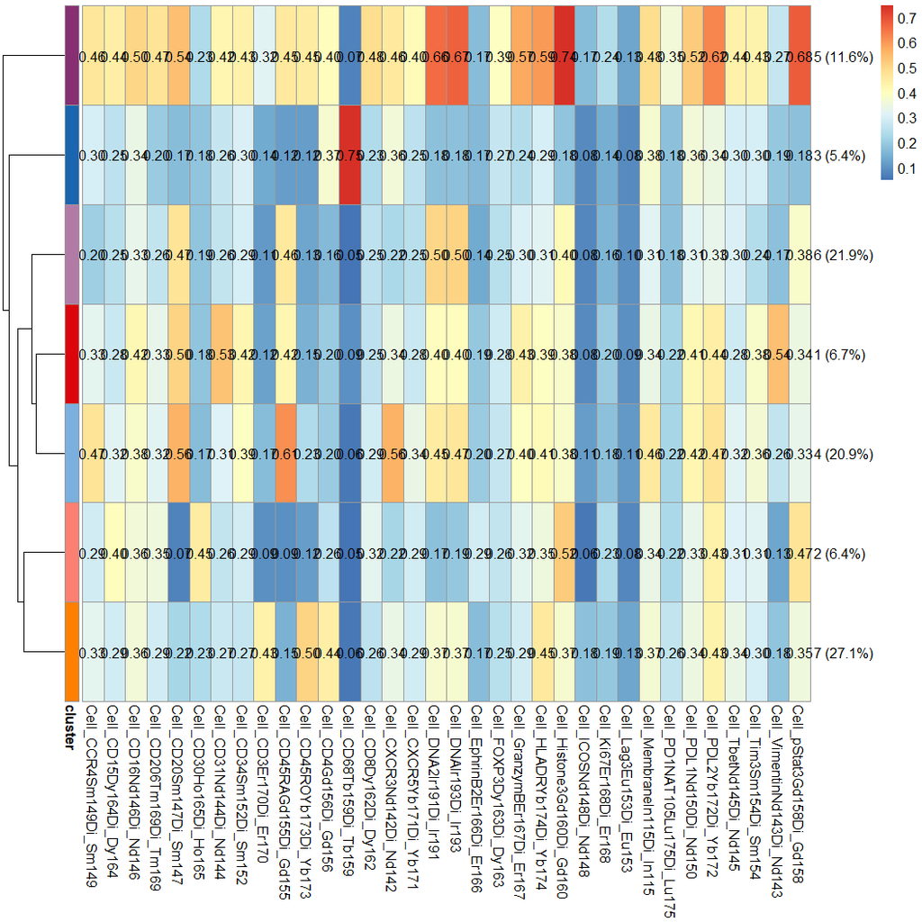

```r
  ##plot phenograph
  plot_clustering_heatmap_wrapper(myExperiment=imc)
```

### histoCAT analysis

- raw input from histoCAT and creating an IMC container.
- containerizes the intensities, neighborhood results, morphology, and computes nearest distances and stores it.
- Can use a hyperframe to identify distances quickly.

```r
 ###

### reading in a directory of histoCAT csv files.

 ##need to reconstruct the fold revised IMC data.
  ##merges a folder full of histoCAT csv files.
 # use morphology and the 1-10 neighbors.
  dataSet<-NULL
 for(i in c("case8.csv","case5.csv")){
  message(i)
    fpath <- system.file("extdata", i, package="imcExperiment")
    case1<-read.csv(fpath)
   proteins<-colnames(case1)[grepl("Cell_",colnames(case1))]
   neig<-colnames(case1)[grepl("neighbour_",colnames(case1))][1:10]
    case1<-case1[,c("ImageId","CellId","X_position","Y_position",proteins,
                    "Area",
                    "Eccentricity",
    "Solidity",
    "Extent",
    "Perimeter",
     neig)]
    dataSet<-rbind(dataSet,case1)
  }
```

```
## case8.csv
```

```
## case5.csv
```

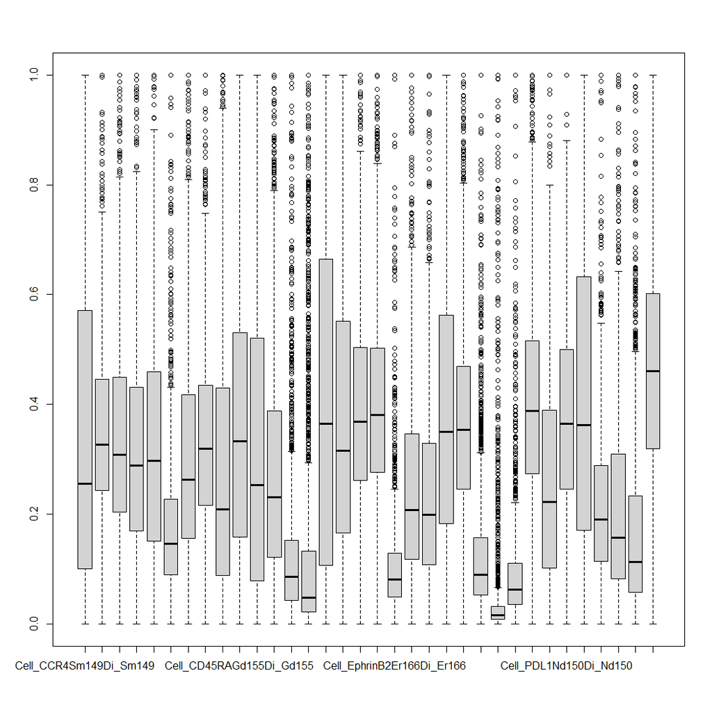

```r
 expr<-dataSet[,proteins]
  normExp<-percentilenormalize(data=expr,percentile=0.99)
  normExp<-as.matrix(normExp)
  boxplot(normExp)
```

```r
  ##spatial component
  spatial<-(dataSet[,c("X_position","Y_position")])
  spatial<-as.matrix(spatial)
 ##uniqueLabel
  uniqueLabel<-paste0(dataSet[,"ImageId"],"_",dataSet[,"CellId"])

  ##not yet assigned
  phenotypes<-matrix(0,nrow(dataSet),1)
  ROIID=data.frame(ROIID=dataSet[,"ImageId"])
  morph<-dataSet[,c("Area",
                    "Eccentricity",
    "Solidity",
    "Extent",
    "Perimeter")]

  x<-imcExperiment(cellIntensity=t(normExp),
    coordinates=spatial,
    neighborHood=as.matrix(dataSet[,grepl("neighbour_",colnames(dataSet))]),
    network=phenotypes,
    distance=matrix(1,nrow=nrow(dataSet),ncol=10),
    morphology=morph,
    panel=colnames(normExp),
    uniqueLabel=uniqueLabel,
    ROIID=ROIID)
   x
```

```
## class: imcExperiment
## dim: 34 2000
## metadata(0):
## assays(1): counts
## rownames(34): Cell_CCR4Sm149Di_Sm149 Cell_CD15Dy164Di_Dy164 ...
##   Cell_VimentinNd143Di_Nd143 Cell_pStat3Gd158Di_Gd158
## rowData names(0):
## colnames(2000): 372149_1 372149_2 ... 274864_999 274864_1000
## colData names(1): ROIID
## reducedDimNames(0):
## altExpNames(0):
```

```r
  ##phenotype
  ##run phenograph
  require(Rphenograph)
  phenos<-Rphenograph(t(cellIntensity(x)),k=35)
   pheno.labels<-as.numeric(membership(phenos[[2]]))
   getNetwork(x)<-matrix(pheno.labels)
    head(getNetwork(x))
```

```
##      [,1]
## [1,]    7
## [2,]    6
## [3,]    5
## [4,]    4
## [5,]    7
## [6,]    1
```

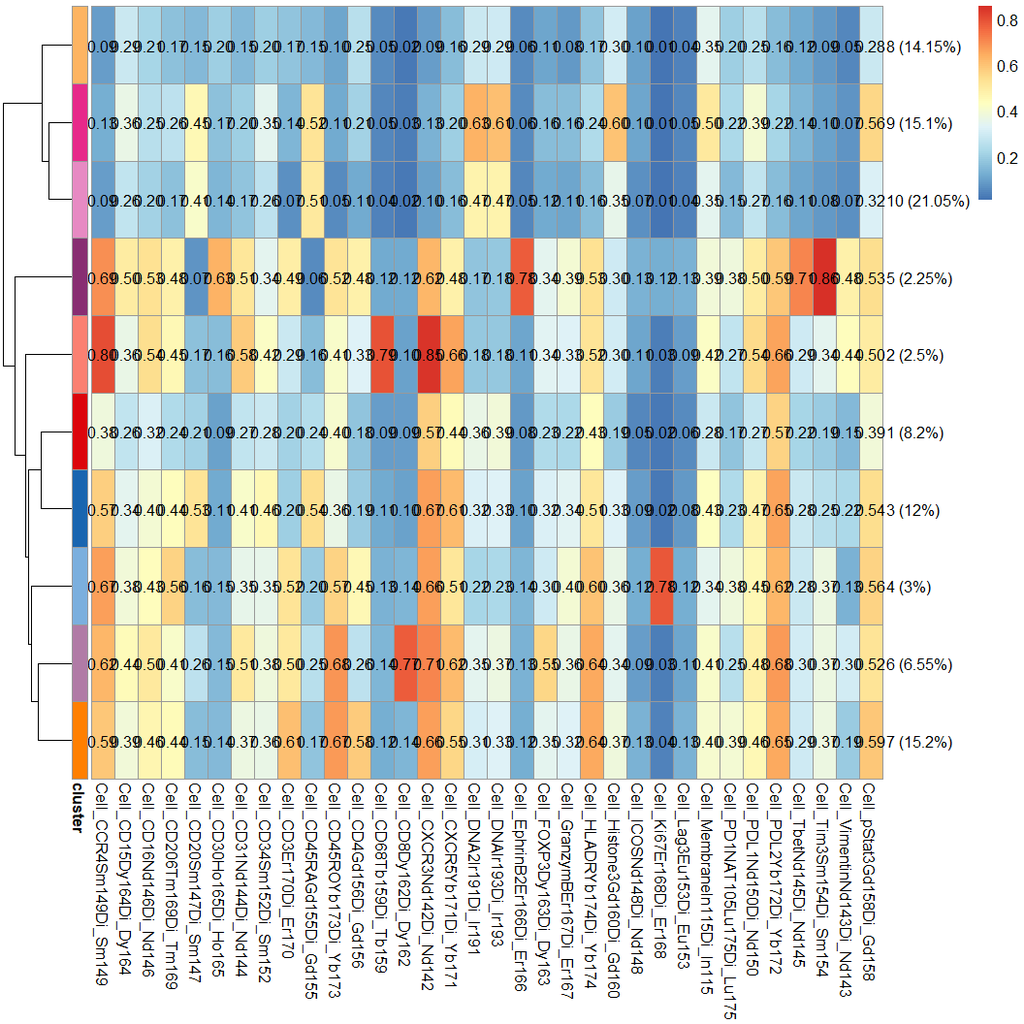

```r
  ##plot phenograph
  plot_clustering_heatmap_wrapper(myExperiment=x)
```

### Access unique cell ID

- getLabel(), we can access unique cell ID
- subsetCase(x,ROIID) can subset to a single ROIID
- selectCases(x,c(“ROI1”,“ROI2”,“ROI3”)) selects a subset of multiple ROIs.

```r
 ##store the ROIID in the metadata columns.
  ##access the unique cell labels.
  head(getLabel(x))
```

```
## [1] "372149_1" "372149_2" "372149_3" "372149_4" "372149_5" "372149_6"
```

```r
  roi<-subsetCase(x,372149 )
  roi
```

```
## class: imcExperiment
## dim: 34 1000
## metadata(0):
## assays(1): counts
## rownames(34): Cell_CCR4Sm149Di_Sm149 Cell_CD15Dy164Di_Dy164 ...
##   Cell_VimentinNd143Di_Nd143 Cell_pStat3Gd158Di_Gd158
## rowData names(0):
## colnames(1000): 372149_1 372149_2 ... 372149_999 372149_1000
## colData names(1): ROIID
## reducedDimNames(0):
## altExpNames(0):
```

## Distance computations speedily

- The function ’imcExperimentToHyperFrame(), creates a point pattern useful for distance measures.
- Given a hyperframe pairwise computations can be done.

```r
  ##you can append more clinical features to the columns of the sampleDat data.frame.
  H<-imcExperimentToHyperFrame(imcExperiment=x)
  helper<-function(pp=NULL,i=NULL,j=NULL){
  ps<-split(pp)
  nnd<-nncross(ps[[i]],ps[[j]])
  }
 ## 1-NN analysis.
  ## compare cluster 10 to cluster 9
   eachNND<-with(H,helper(pp=point,i="10",j="8"))
 ## first choose 2 clusters to compare.
  sapply(eachNND,function(x) mean(x[,"dist"]))
```

```
##         1        11
##  15.14001 123.09899
```

### Changing class from IMC to SummarizedExperiment

- IMC container can change to SummarizedExperiment and the FlowSOM algorithm can be used for cell classification.

```r
  library(CATALYST)
library(cowplot)
library(flowCore)
library(ggplot2)
library(SingleCellExperiment)
library(diffcyt)

 ## from IMCexperiment to SCE
 sce<- SingleCellExperiment(x)
 class(sce)
```

```
## [1] "SingleCellExperiment"
## attr(,"package")
## [1] "SingleCellExperiment"
```

```r
 ## FIX ME: add the SOM algorithms for over-clustering and meta-clustering by using class inheritance.

 #### for the cytof, the columns are sample info and the rows are cells. it uses the SummarizedExperiment format.



 ## change into a flowFrame?

 ## change into a daFrame (CATALYST)

 data("imcData")


 rd<-DataFrame(colData(imcData))

  marker_info<-data.frame(channel_name=sapply(strsplit(rownames(imcData),"_"),function(x) x[3]),
              marker_name=rownames(imcData),
              marker_class=c(rep("type",13),
                             rep("state",18),
                             rep("none",13)))

  ## Switching into Summarized Experiment class.
    dse<-SummarizedExperiment(assays=SimpleList(exprs=t(cellIntensity(imcData))),
                           rowData=rd,
                           colData=DataFrame(marker_info)
                           )
   stopifnot(all(colnames(dse)==marker_info$marker_name))
   dse
```

```
## class: SummarizedExperiment
## dim: 2452 44
## metadata(0):
## assays(1): exprs
## rownames(2452): 636895_1 636895_2 ... 1047542_363 1047542_364
## rowData names(18): ROIID ImageId ... Cyto1q Normal
## colnames(44): Cell_CD11b_Sm149 Cell_CD138_Eu151 ... Cell_208Pb_Pb208
##   Cell_80ArAr_ArAr80
## colData names(3): channel_name marker_name marker_class
```

```
## [1] 30 45
```

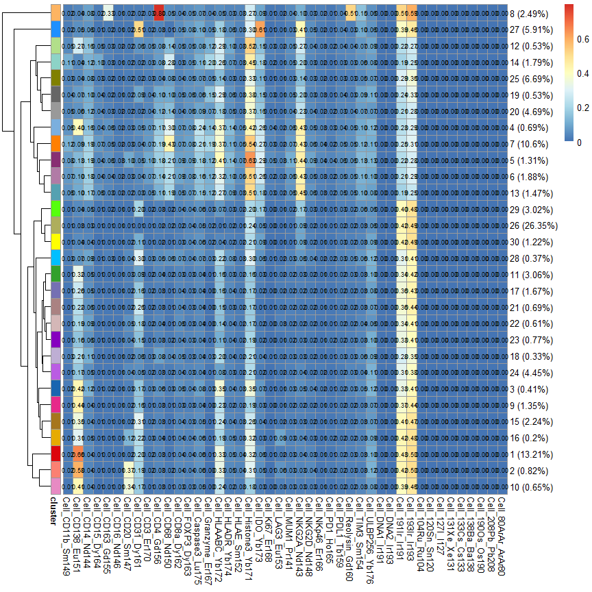

```r
 # Transform data recommended
 dse <- transformData(dse)
## maybe look a the normalization.
# Generate clusters
dse <- (generateClusters(dse,meta_clustering=TRUE,meta_k=30,seed_clustering=828))

 ## examine each cluster.
cluster<-rowData(dse)
 data<-data.frame(t(logcounts(imcData)),cluster)
 plot_matrix_heatmap_wrapper(expr=data[,rownames(imcData)],
                                 cell_clustering=data$cluster_id)
```

## IMC and flowSet conversions

- utilize CATALYST package for IMC we can see scatter plots after converting to FlowSets.
- the rownames for IMC are set to the panel names, and we can split these to create the marker and metal.
- The ROIID is useful for quickly creating a FlowSet object as a class inheritance method.
- The rownames of IMC container are usually in “Cell_Marker_ChannelMetal”

```r
# library(CATALYST)
#data(sample_ff)
#data(sample_key)
#head(sample_key)
 #sce <- prepData(sample_ff)
  #plotScatter(sce,rownames(sce)[1:2])
  ## the bar code ID events,
  # the rows are the bar code channels
   #(fs <- sce2fcs(sce, split_by = "sample_id"))

 ## key notes for strucutre improvements.
   #subsetting x SCE to y results in SCE
   # y <- x[i, , drop = FALSE]
    ## using 'assay' method, returns a matrix.
#  y <- assay(y, 'counts')
   ## and should be a class matrix,assay
 #   y <- t(assay(x, 'counts'))

 ## improving the IMC class structure.
   ## the assay returns matrix class! required for CATALYST.
  is(assay(imcData,'counts'),'matrix')
```

```
## [1] TRUE
```

```r
  rownames(imcData)
```

```
##  [1] "Cell_CD11b_Sm149"    "Cell_CD138_Eu151"    "Cell_CD14_Nd144"
##  [4] "Cell_CD15_Dy164"     "Cell_CD163_Gd155"    "Cell_CD16_Nd146"
##  [7] "Cell_CD20_Sm147"     "Cell_CD31_Dy161"     "Cell_CD3_Er170"
## [10] "Cell_CD4_Gd156"      "Cell_CD68_Nd150"     "Cell_CD8a_Dy162"
## [13] "Cell_FOXP3_Dy163"    "Cell_Caspase3_Lu175" "Cell_Granzyme_Er167"
## [16] "Cell_HLAABC_Yb172"   "Cell_HLADR_Yb174"    "Cell_HLAE_Sm152"
## [19] "Cell_Histone3_Yb171" "Cell_IDO_Yb173"      "Cell_Ki67_Er168"
## [22] "Cell_LAG3_Eu153"     "Cell_MUM1_Pr141"     "Cell_NKG2A_Nd143"
## [25] "Cell_NKG2D_Nd148"    "Cell_NKp46_Er166"    "Cell_PD1_Ho165"
## [28] "Cell_PDL1_Tb159"     "Cell_Reolysin_Gd160" "Cell_TIM3_Sm154"
## [31] "Cell_ULBP256_Yb176"  "Cell_DNA1_Ir191"     "Cell_DNA2_Ir193"
## [34] "Cell_191Ir_Ir191"    "Cell_193Ir_Ir193"    "Cell_104Ru_Ru104"
## [37] "Cell_120Sn_Sn120"    "Cell_127I_I127"      "Cell_131Xe_Xe131"
## [40] "Cell_133Cs_Cs133"    "Cell_138Ba_Ba138"    "Cell_190Os_Os190"
## [43] "Cell_208Pb_Pb208"    "Cell_80ArAr_ArAr80"
```

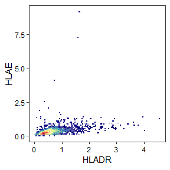

```r
    # for plot scatter to work need to set the rowData feature in a specific way.
   channel<-sapply(strsplit(rownames(imcData),"_"),function(x) x[3])
      channel[34:35]<-c("Ir1911","Ir1931")

   marker<-sapply(strsplit(rownames(imcData),"_"),function(x) x[2])
    rowData(imcData)<-DataFrame(channel_name=channel,marker_name=marker)
      rownames(imcData)<-marker
            plotScatter(imcData,rownames(imcData)[17:18],assay='counts')
```

```r
  # convert to flowSet
             ## the warning has to do with duplicated Iridium channels.
   table(colData(imcData)$ROIID)
```

```
##
##     30-BM16-202_7Pre_s1_p1_r4_a4_ac    30-BM16-527-9Post_s1_p1_r5_a5_ac
##                                 471                                 450
## 30-BM17-415_12pre(1)_s1_p1_r4_a4_ac       B17_350_14post_s1_p1_r4_a4_ac
##                                 617                                 550
##       B17_350_14post_s1_p1_r5_a5_ac
##                                 364
```

```r
       (fsimc <- sce2fcs(imcData, split_by = "ROIID"))
```

```
## A flowSet with 5 experiments.
##
## column names(44): Sm149 Eu151 ... Pb208 ArAr80
```

```r
    ## now we have a flowSet.
   pData(fsimc)
```

```
##                                                                    name
## 30-BM16-202_7Pre_s1_p1_r4_a4_ac         30-BM16-202_7Pre_s1_p1_r4_a4_ac
## 30-BM16-527-9Post_s1_p1_r5_a5_ac       30-BM16-527-9Post_s1_p1_r5_a5_ac
## 30-BM17-415_12pre(1)_s1_p1_r4_a4_ac 30-BM17-415_12pre(1)_s1_p1_r4_a4_ac
## B17_350_14post_s1_p1_r4_a4_ac             B17_350_14post_s1_p1_r4_a4_ac
## B17_350_14post_s1_p1_r5_a5_ac             B17_350_14post_s1_p1_r5_a5_ac
```

```r
   fsApply(fsimc,nrow)
```

```
##                                     [,1]
## 30-BM16-202_7Pre_s1_p1_r4_a4_ac      471
## 30-BM16-527-9Post_s1_p1_r5_a5_ac     450
## 30-BM17-415_12pre(1)_s1_p1_r4_a4_ac  617
## B17_350_14post_s1_p1_r4_a4_ac        550
## B17_350_14post_s1_p1_r5_a5_ac        364
```

```r
   dim(exprs(fsimc[[1]]))
```

```
## [1] 471  44
```

```r
   exprs(fsimc[[1]])[1:5,1:5]
```

```
##          Sm149     Eu151     Nd144      Dy164      Gd155
## [1,] 0.2566372 0.6902655 0.3805310 0.13274336 0.19469027
## [2,] 0.3043478 0.7336956 0.3532609 0.06521739 0.26630434
## [3,] 0.1666667 0.2368421 0.2368421 0.04385965 0.09649123
## [4,] 0.3385417 0.5677083 0.4270833 0.51562500 0.26562500
## [5,] 0.1666667 0.2948718 0.2564103 0.07692308 0.10256410
```

```r
    ## set up the metadata files.
   head(marker_info)
```

```
##   channel_name      marker_name marker_class
## 1        Sm149 Cell_CD11b_Sm149         type
## 2        Eu151 Cell_CD138_Eu151         type
## 3        Nd144  Cell_CD14_Nd144         type
## 4        Dy164  Cell_CD15_Dy164         type
## 5        Gd155 Cell_CD163_Gd155         type
## 6        Nd146  Cell_CD16_Nd146         type
```

```r
    exper_info<-data.frame(group_id=colData(imcData)$Treatment[match(pData(fsimc)$name,colData(imcData)$ROIID)],
                           patient_id=colData(imcData)$Patient.Number[match(pData(fsimc)$name,colData(imcData)$ROIID)],
                           sample_id=pData(fsimc)$name)

   ## create design
   design<-createDesignMatrix(
     exper_info,cols_design=c("group_id","patient_id"))

   ##set up contrast
   contrast<-createContrast(c(0,1,0))
   nrow(contrast)==ncol(design)
```

```
## [1] TRUE
```

```r
   data.frame(parameters=colnames(design),contrast)
```

```
##    parameters contrast
## 1 (Intercept)        0
## 2 group_idPRE        1
## 3  patient_id        0
```

```r
    ## flowSet to DiffCyt
    out_DA<-diffcyt(
      d_input=fsimc,
      experiment_info=exper_info,
      marker_info=marker_info,
      design=design,
      contrast=contrast,
      analysis_type = "DA",
      seed_clustering = 123
    )
   topTable(out_DA,format_vals = TRUE)
```

```
## DataFrame with 20 rows and 3 columns
##     cluster_id     p_val     p_adj
##       <factor> <numeric> <numeric>
## 86         86     0.0293     0.461
## 100        100    0.0512     0.461
## 76         76     0.1950     0.904
## 87         87     0.2010     0.904
## 10         10     0.7770     0.967
## ...        ...       ...       ...
## 97          97     0.363     0.967
## 98          98     0.627     0.967
## 80          80     0.994     0.994
## 1           1         NA        NA
## 2           2         NA        NA
```

```r
   out_DS<-diffcyt(
     d_input=fsimc,
     experiment_info=exper_info,
     marker_info=marker_info,
     design=design,
     contrast=contrast,
     analysis_type='DS',
     seed_clustering = 123,
     plot=FALSE)

      topTable(out_DS,format_vals = TRUE)
```

```
## DataFrame with 20 rows and 4 columns
##     cluster_id           marker_id     p_val     p_adj
##       <factor>            <factor> <numeric> <numeric>
## 100        100 Cell_Caspase3_Lu175  0.000886    0.0412
## 10         10  Cell_Granzyme_Er167  0.000877    0.0412
## 100        100 Cell_Granzyme_Er167  0.000313    0.0412
## 56         56  Cell_NKG2A_Nd143     0.000891    0.0412
## 76         76  Cell_NKG2A_Nd143     0.000208    0.0412
## ...        ...                 ...       ...       ...
## 100        100 Cell_Histone3_Yb171   0.00876     0.188
## 70         70  Cell_Ki67_Er168       0.01050     0.188
## 100        100 Cell_PDL1_Tb159       0.01040     0.188
## 95         95  Cell_Caspase3_Lu175   0.01370     0.192
## 100        100 Cell_IDO_Yb173        0.01280     0.192
```

```r
       ### from flowSet to SE.
 d_se<-prepareData(fsimc,exper_info,marker_info)
```

### Diffcyt package tutorial (extra)

- Given a flowSet object we can utilize the diffCyt package for measuring phenotype differences.
- This code section is an example of diffcyt from their manual.
- Creates a random summarized experiment.

```r
 library(diffcyt)
# Function to create random data (one sample)
d_random <- function(n = 20000, mean = 0, sd = 1, ncol = 20, cofactor = 5) {
  d <- sinh(matrix(rnorm(n, mean, sd), ncol = ncol)) * cofactor
  colnames(d) <- paste0("marker", sprintf("%02d", 1:ncol))
  d
}

# Create random data (without differential signal)
set.seed(123)
d_input <- list(
  sample1 = d_random(),
  sample2 = d_random(),
  sample3 = d_random(),
  sample4 = d_random()
)

experiment_info <- data.frame(
  sample_id = factor(paste0("sample", 1:4)),
  group_id = factor(c("group1", "group1", "group2", "group2")),
  stringsAsFactors = FALSE
)

marker_info <- data.frame(
  channel_name = paste0("channel", sprintf("%03d", 1:20)),
  marker_name = paste0("marker", sprintf("%02d", 1:20)),
  marker_class = factor(c(rep("type", 10), rep("state", 10)),
                        levels = c("type", "state", "none")),
  stringsAsFactors = FALSE
)

# Prepare data
d_se <- prepareData(d_input, experiment_info, marker_info)

# Transform data
d_se <- transformData(d_se)

# Generate clusters
d_se <- generateClusters(d_se)
```

```
## FlowSOM clustering completed in 0.2 seconds
```